# Digital health project

5. Heat map

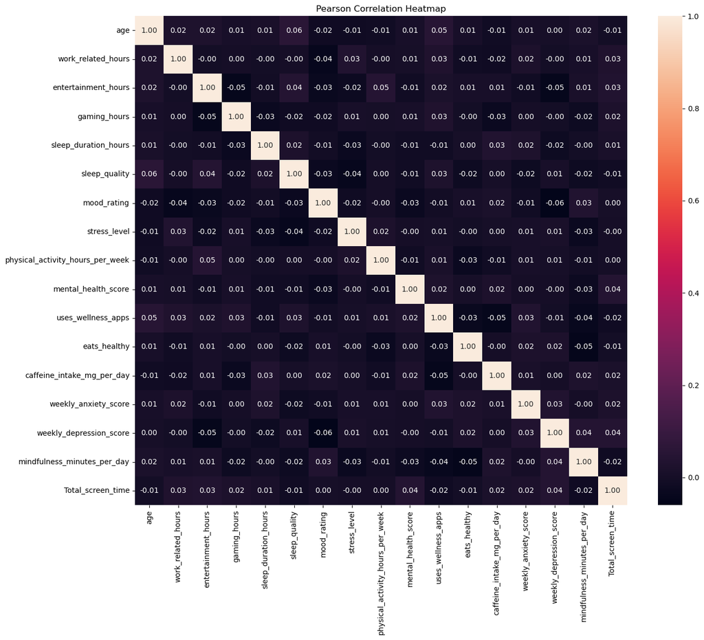

```python
plt.figure(figsize=(15, 12))
sns.heatmap(df.corr(numeric_only=True), annot=True, fmt=".2f")
plt.title("Pearson Correlation Heatmap")
plt.show()
```

Interpretation: The heatmap shows very weak correlations between mental health score and all other variables, including lifestyle factors like physical activity, screen time, sleep, and wellness app usage. All correlation coefficients are near zero, indicating no strong linear relationships. The highest correlation in the matrix (around ±0.06) is still minimal, suggesting that no individual feature has a significant direct impact on mental health score in isolation.

FEATURE SELECTION

```python
df = df.drop(columns=['user_id', 'mood_rating'])
df
```

|  | age | gender | work_related_hours | entertainment_hours | gaming_hours | sleep_duration_hours | sleep_quality | stress_level | physical_activity_hours_per_week | location_type | mental_health_score | uses_wellness_apps | eats_healthy | caffeine_intake_mg_per_day | weekly_anxiety_score | weekly_depression_score | mindfulness_minutes_per_day | Total_screen_time |
| --- | --- | --- | --- | --- | --- | --- | --- | --- | --- | --- | --- | --- | --- | --- | --- | --- | --- | --- |
| 0 | 51 | Female | 2.0 | 1.0 | 1.7 | 6.6 | 6 | 10 | 0.7 | Urban | 32 | 1 | 1 | 125.2 | 13 | 15 | 4.0 | 16.8 |
| 1 | 64 | Male | 3.1 | 1.0 | 1.5 | 4.5 | 7 | 6 | 4.3 | Suburban | 75 | 0 | 1 | 150.4 | 19 | 18 | 6.5 | 14.8 |
| 2 | 41 | Other | 2.8 | 4.1 | 1.7 | 7.1 | 9 | 5 | 3.1 | Suburban | 22 | 0 | 0 | 187.9 | 7 | 3 | 6.9 | 21.1 |
| 3 | 27 | Other | 1.6 | 1.3 | 0.4 | 5.1 | 9 | 5 | 0.0 | Rural | 22 | 0 | 1 | 73.6 | 7 | 2 | 4.8 | 15.3 |
| 4 | 55 | Male | 3.6 | 0.8 | 0.8 | 7.4 | 2 | 7 | 3.0 | Urban | 64 | 1 | 1 | 217.5 | 8 | 10 | 0.0 | 12.9 |
| ... | ... | ... | ... | ... | ... | ... | ... | ... | ... | ... | ... | ... | ... | ... | ... | ... | ... | ... |
| 1995 | 58 | Female | 1.2 | 2.1 | 0.8 | 6.0 | 6 | 9 | 0.0 | Urban | 62 | 0 | 1 | 164.9 | 20 | 17 | 4.9 | 15.0 |
| 1996 | 62 | Female | 4.1 | 6.4 | 1.8 | 6.2 | 10 | 8 | 2.7 | Urban | 29 | 0 | 0 | 172.6 | 15 | 15 | 25.5 | 13.3 |
| 1997 | 64 | Female | 2.6 | 4.1 | 2.5 | 6.5 | 3 | 4 | 6.5 | Urban | 54 | 1 | 0 | 101.3 | 1 | 20 | 9.5 | 13.5 |
| 1998 | 19 | Male | 1.2 | 2.0 | 0.7 | 7.1 | 1 | 8 | 2.6 | Urban | 28 | 0 | 0 | 123.7 | 1 | 11 | 13.4 | 14.9 |
| 1999 | 15 | Female | 1.8 | 3.5 | 0.9 | 5.9 | 5 | 10 | 6.3 | Urban | 59 | 1 | 0 | 173.1 | 0 | 17 | 10.0 | 15.2 |

2000 rows × 18 columns

```python
df.info()
```

```
<class 'pandas.core.frame.DataFrame'>
RangeIndex: 2000 entries, 0 to 1999
Data columns (total 18 columns):
 #   Column                            Non-Null Count  Dtype
---  ------                            --------------  -----
 0   age                               2000 non-null   int64
 1   gender                            2000 non-null   object
 2   work_related_hours                2000 non-null   float64
 3   entertainment_hours               2000 non-null   float64
 4   gaming_hours                      2000 non-null   float64
 5   sleep_duration_hours              2000 non-null   float64
 6   sleep_quality                     2000 non-null   int64
 7   stress_level                      2000 non-null   int64
 8   physical_activity_hours_per_week  2000 non-null   float64
 9   location_type                     2000 non-null   object
 10  mental_health_score               2000 non-null   int64
 11  uses_wellness_apps                2000 non-null   int64
 12  eats_healthy                      2000 non-null   int64
 13  caffeine_intake_mg_per_day        2000 non-null   float64
 14  weekly_anxiety_score              2000 non-null   int64
 15  weekly_depression_score           2000 non-null   int64
 16  mindfulness_minutes_per_day       2000 non-null   float64
 17  Total_screen_time                 2000 non-null   float64
dtypes: float64(8), int64(8), object(2)
memory usage: 281.4+ KB
```

```python
# Convert gender to numeric
df['gender'] = df['gender'].map({'Female': 0, 'Male': 1, 'Other': 2})

# Convert location_type to numeric
df['location_type'] = df['location_type'].map({'Urban': 0, 'Rural': 1, 'Suburban': 2})
```

```python
df.columns
```

```
Index(['age', 'gender', 'work_related_hours', 'entertainment_hours',
       'gaming_hours', 'sleep_duration_hours', 'sleep_quality', 'stress_level',
       'physical_activity_hours_per_week', 'location_type',
       'mental_health_score', 'uses_wellness_apps', 'eats_healthy',
       'caffeine_intake_mg_per_day', 'weekly_anxiety_score',
       'weekly_depression_score', 'mindfulness_minutes_per_day',
       'Total_screen_time'],
      dtype='object')
```

```python
X = df[[
    "age", "gender", "work_related_hours", "entertainment_hours",
    "gaming_hours", "sleep_duration_hours", "sleep_quality", "stress_level",
    "physical_activity_hours_per_week", "location_type", "uses_wellness_apps",
    "eats_healthy", "caffeine_intake_mg_per_day", "weekly_anxiety_score",
    "weekly_depression_score", "mindfulness_minutes_per_day", "Total_screen_time"
]]

y = df["mental_health_score"]
```